# Practical Machine Learning Project

David Hachuel

Wednesday, August 19, 2015

## Executive Summary

Using devices such as Jawbone Up, Nike FuelBand, and Fitbit it is now possible to collect a large amount of data about personal activity relatively inexpensively. These type of devices are part of the quantified self movement – a group of enthusiasts who take measurements about themselves regularly to improve their health, to find patterns in their behavior, or because they are tech geeks. One thing that people regularly do is quantify how much of a particular activity they do, but they rarely quantify how well they do it. In this project, your goal will be to use data from accelerometers on the belt, forearm, arm, and dumbell of 6 participants. They were asked to perform barbell lifts correctly and incorrectly in 5 different ways. More information is available from the website here: http://groupware.les.inf.puc-rio.br/har (see the section on the Weight Lifting Exercise Dataset).

The goal of this project is to predict the manner of performing unilateral dumbbell biceps curls based on data from accelerometers on the belt, forearm, arm, and dumbell of 6 participants. The 5 possible methods include -

A: exactly according to the specification B: throwing the elbows to the front C: lifting the dumbbell only halfway D: lowering the dumbbell only halfway E: throwing the hips to the front

## Setting Up Environment (packages and settings)

In addition to the machine learning related packages (random forests and caret), **reshape** is used to transform data for plotting purposes and the pseudo-random number generator seed is set to guarantee reproducibility.

```r
# ENVIRONMENT SET UP
suppressMessages(library(caret))
suppressMessages(library(ggplot2))
suppressMessages(library(randomForest))
suppressMessages(library(reshape2))
set.seed(1)
```

Here is the output function used to export test cases to text file.

```r
# HELPER FUNCTION
pml_write_files = function(x){
  n = length(x)
  for(i in 1:n){
    filename = paste0("problem_id_",i,".txt")
    write.table(x[i],file=filename,quote=FALSE,row.names=FALSE,col.names=FALSE)
  }
}
```

## Data Loading and Cleaning

```r
# Load datA
training <- read.table(
  file = "pml-training.csv",
  header = TRUE,
  na.strings=c("NA","#DIV/0!",""),
  sep = ","
)
testing <- read.table(
  file = "pml-testing.csv",
  header = TRUE,
  na.strings=c("NA","#DIV/0!",""),
  sep = ","
)
```

When cleaning data, it is important to make sure that all features used during training have a value in the test data set. It is also important to make sure that all variable “make sense” as feature. For instance, the **username** variable doesn’t make sense as a model feature.

```r
# Remove NA fields equally from both training and test data sets
training.clean <- training[,colSums(is.na(training)) == 0]
testing.clean <- testing[,colSums(is.na(testing)) == 0]

# Remove unrelated fields such as timestamp or usernames (fields 1 through 7)
training.clean <- training.clean[,-c(1:7)]
testing.clean <- testing.clean[,-c(1:7)]
```

## Exploratory Feature Analysis

For visual purposes, it is interesting to plot the distribution of each numerical variable segmented by the *class* factor variable.

[figure not shown]

```r
# Select numeric fields
training.clean2 <- training.clean
training.clean2$classe <- as.numeric(training.clean2$classe)
numeric_cols <- sapply(training.clean2, is.numeric)

# Melt dataset using reshape
training.clean.lng <- melt(training.clean2[,numeric_cols], id="classe")

# Plot the distribution for each classe in a given variable
ggplot(aes(x=value, group=classe, colour=factor(classe)), data=training.clean.lng) +
  geom_density() +
  facet_wrap(~variable, scales="free") +
  ggtitle("Exploratory Feature Distribution Plot")
```

```r
# Remove unused data sets to rpeserve memory
rm(training.clean2)
rm(training.clean.lng)
```

## Model Calibration

For calibration purpose, the training data set will be split into train (60%) and test sets (40%).

```r
# Splitting the training set for calibration
idx <- runif(nrow(training.clean)) > 0.6
train <- training.clean[idx==FALSE,]
test <- training.clean[idx==TRUE,]
```

One property of machine learning algorithms is that they are heavily parametrized. In other words, they require input parameter fine tuning to obtain optimal results. For this model, the random forest algorithm requires tuning of two main parameters:

#### MTRY (number of variable to randomly try at each tree split)

```r
# Tuning mtry parameter
tune.rf <- tuneRF(x = train[,-53],y = train[,53], stepFactor=0.5, mtryStart = 2, ntreeTry = 500)
```

```
## mtry = 2  OOB error = 0.84%
## Searching left ...
## mtry = 4     OOB error = 0.73%
## 0.1313131 0.05
## mtry = 8     OOB error = 0.66%
## 0.09302326 0.05
## mtry = 16    OOB error = 0.68%
## -0.02564103 0.05
## Searching right ...
## mtry = 1     OOB error = 1.37%
## -1.076923 0.05
```

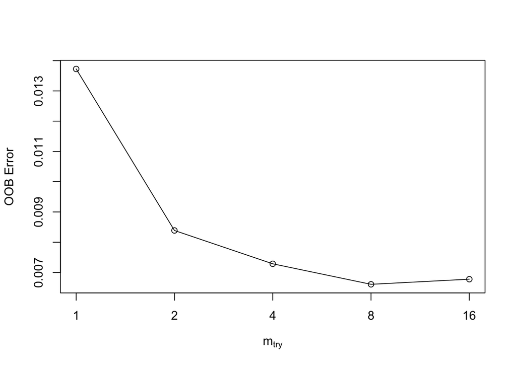

#### NTREE (number of trees to grow in the forest)

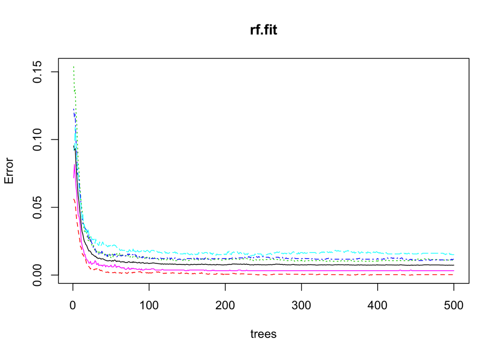

```r
rf.fit <- randomForest(factor(classe)~.,data=train, mtry=16, ntree=500, na.action=na.omit)
plot(rf.fit) # plotting OOB error rate for each class and global
```

```r
print(rf.fit$confusion) # print OOB confusion matrix
```

```
##      A    B    C    D    E  class.error
## A 3386    1    0    0    0 0.0002952465
## B   18 2241    7    0    0 0.0110326567
## C    0   18 2031    6    0 0.0116788321
## D    0    2   26 1896    1 0.0150649351
## E    0    0    3    4 2163 0.0032258065
```

It definitely looks like 500 trees is more than enough to stabilize the OOB error rate.

Here are the testing result when applying the preliminary calibrated model to the test data set.

```r
# Test Model
rf.predict = predict(rf.fit,newdata=test)
confusionMatrix(rf.predict, test$classe)
```

```
## Confusion Matrix and Statistics
##
##           Reference
## Prediction    A    B    C    D    E
##          A 2192    8    0    0    0
##          B    0 1514   12    0    0
##          C    0    9 1352   15    5
##          D    0    0    3 1276   11
##          E    1    0    0    0 1421
##
## Overall Statistics
##
##                Accuracy : 0.9918
##                  95% CI : (0.9896, 0.9937)
##     No Information Rate : 0.2805
##     P-Value [Acc > NIR] : < 2.2e-16
##
##                   Kappa : 0.9897
##  Mcnemar's Test P-Value : NA
##
## Statistics by Class:
##
##                      Class: A Class: B Class: C Class: D Class: E
## Sensitivity            0.9995   0.9889   0.9890   0.9884   0.9889
## Specificity            0.9986   0.9981   0.9955   0.9979   0.9998
## Pos Pred Value         0.9964   0.9921   0.9790   0.9891   0.9993
## Neg Pred Value         0.9998   0.9973   0.9977   0.9977   0.9975
## Prevalence             0.2805   0.1958   0.1748   0.1651   0.1838
## Detection Rate         0.2803   0.1936   0.1729   0.1632   0.1817
## Detection Prevalence   0.2814   0.1952   0.1766   0.1650   0.1819
## Balanced Accuracy      0.9991   0.9935   0.9923   0.9931   0.9944
```

Note the accuracy is close to 1.

## Final Model and Test Case generation

First let’s train the random forest on the entire training set using the calibrated parameters.

```r
# Train Random Forest on the entire training set
rf.fit.final <- randomForest(factor(classe)~.,data=training.clean, mtry=16, ntree=500, na.action=na.omit)
print(rf.fit.final$confusion) # confusion matrix for OOB observations
```

```
##      A    B    C    D    E  class.error
## A 5576    3    0    0    1 0.0007168459
## B   14 3778    5    0    0 0.0050039505
## C    0    7 3411    4    0 0.0032144944
## D    0    0   18 3194    4 0.0068407960
## E    0    0    3    5 3599 0.0022179096
```

Finally, let’s generate the text files with the test cases predictions.

```r
# Generate test cases and corresponding files
predictions <- predict(rf.fit.final, newdata=testing.clean)
answers <- as.vector(as.character(as.data.frame(predictions)$predictions))
pml_write_files(answers)
```